# Balance in Pokemon Games

Pokemon is one of the most popular video game franchises in the entire world, with over 370 million games sold worldwide, making it the second best-selling video game series in history. Pokemon has been around for over 24 years (first release was in February 1996), and throughout that time, nearly 900 Pokemon have been created.

Pokemon strength is measured by "stats", with higher stats generally equating to stronger Pokemon, and lower stats generally equating to weaker Pokemon. Pokemon can be grouped by many unique variables, including Generation (8 Generations with about 2-5 year gaps between generations), types (18 total types in Pokemon as of Generation 8), and status (Normal, Sub Legendary, Legendary, and Mythical Pokemon).

Pokemon is a very well balanced game in that most of these definining features are all well balanced against one another. In other words, there isn't usually a single kind of Pokemon that would dominate the others (the only exception being Pokemon status, but this is inherently balanced by the scarcity of the more specially classified statuses - more on this in the following sections). The analyses and visualizations below aim to demonstrate this conclusion.

# Stat Distributions by Type

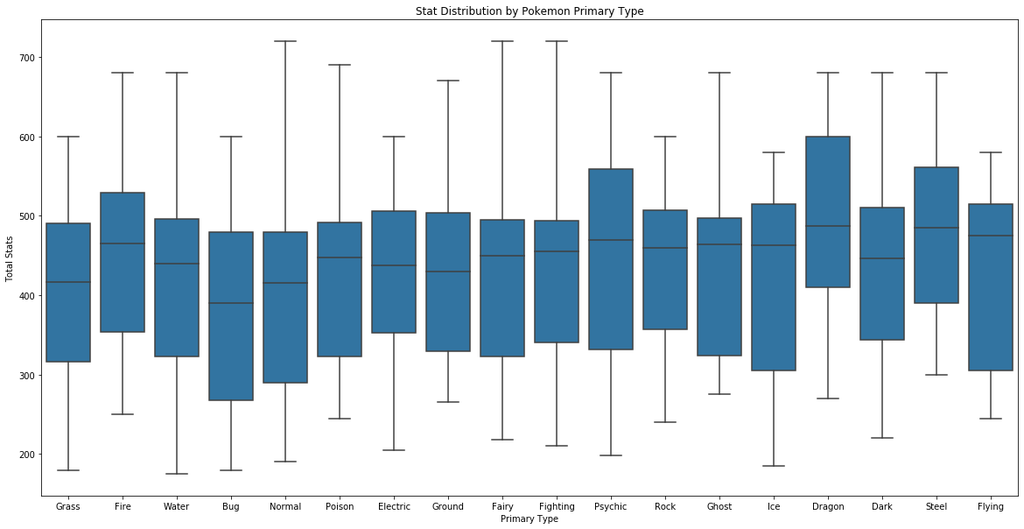

```python
plt.figure(figsize=(20,10))
base_color = sb.color_palette()[0]
sb.boxplot(data=pokemon,x='type_1',y='total_points',color=base_color);
plt.ylabel('Total Stats')
plt.xlabel('Primary Type')
plt.title('Stat Distribution by Pokemon Primary Type');
```

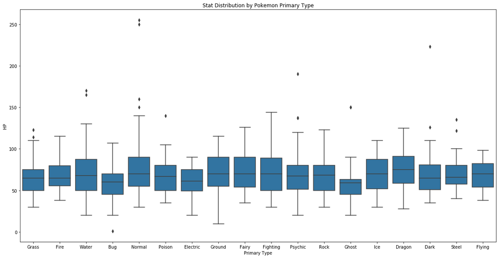

```python
plt.figure(figsize=(20,10))
sb.boxplot(data=pokemon,x='type_1',y='hp',color=base_color);
plt.ylabel('HP')
plt.xlabel('Primary Type')
plt.title('Stat Distribution by Pokemon Primary Type');
```

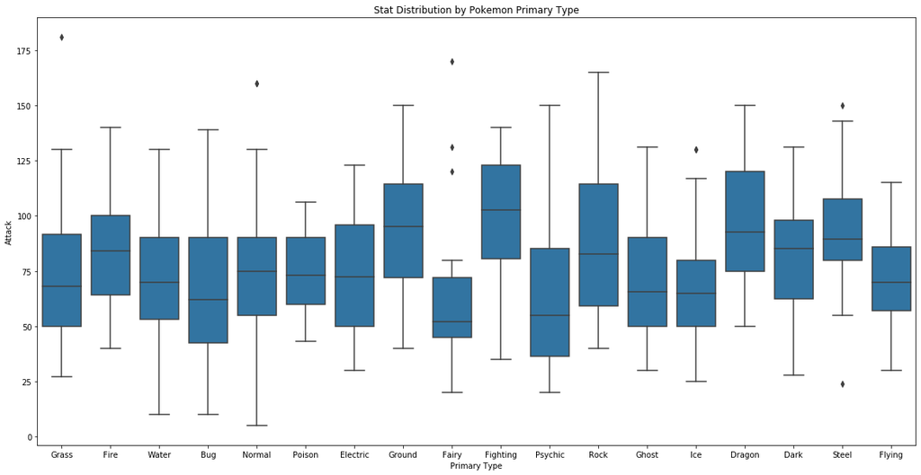

```python
plt.figure(figsize=(20,10))
sb.boxplot(data=pokemon,x='type_1',y='attack',color=base_color);
plt.ylabel('Attack')
plt.xlabel('Primary Type')
plt.title('Stat Distribution by Pokemon Primary Type');
```

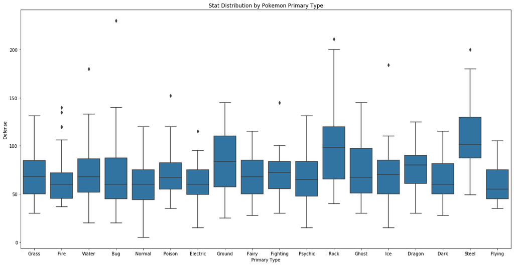

```python
plt.figure(figsize=(20,10))
sb.boxplot(data=pokemon,x='type_1',y='defense',color=base_color);
plt.ylabel('Defense')
plt.xlabel('Primary Type')
plt.title('Stat Distribution by Pokemon Primary Type');
```

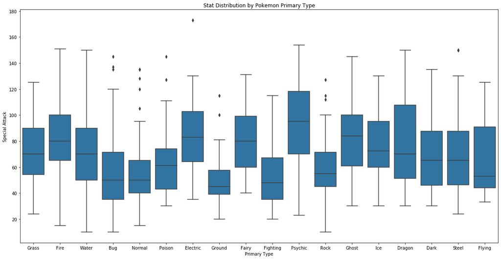

```python
plt.figure(figsize=(20,10))
sb.boxplot(data=pokemon,x='type_1',y='sp_attack',color=base_color);
plt.ylabel('Special Attack')
plt.xlabel('Primary Type')
plt.title('Stat Distribution by Pokemon Primary Type');
```

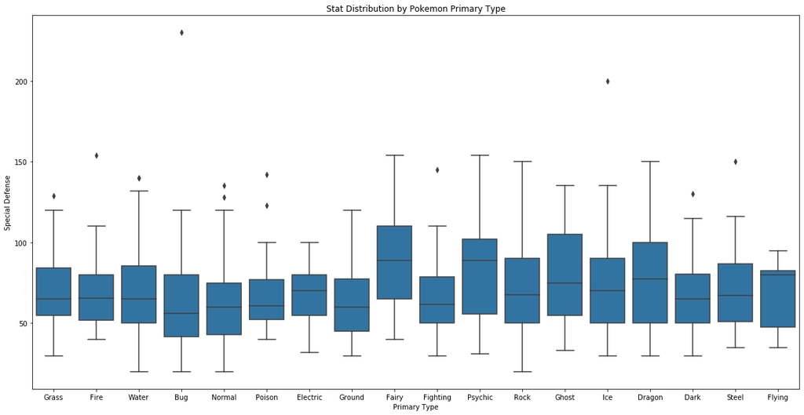

```python
plt.figure(figsize=(20,10))
sb.boxplot(data=pokemon,x='type_1',y='sp_defense',color=base_color);
plt.ylabel('Special Defense')
plt.xlabel('Primary Type')
plt.title('Stat Distribution by Pokemon Primary Type');
```

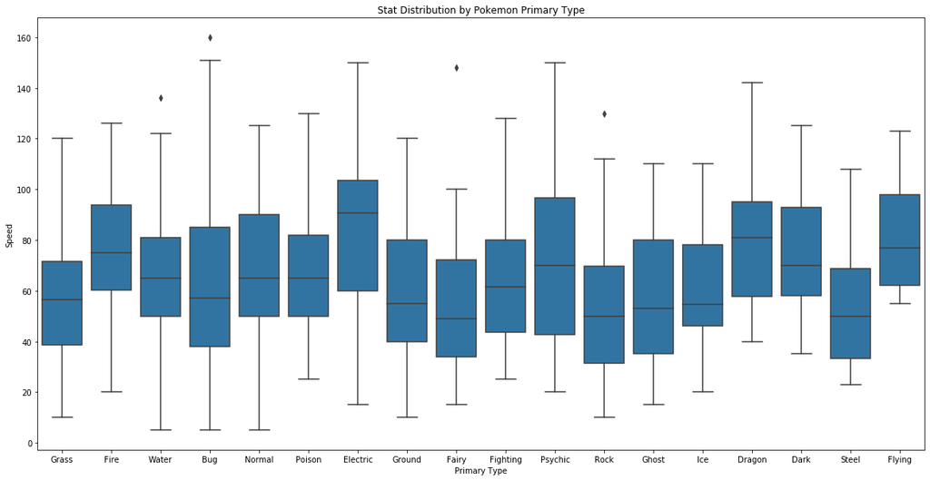

```python
plt.figure(figsize=(20,10))
sb.boxplot(data=pokemon,x='type_1',y='speed',color=base_color);
plt.ylabel('Speed')
plt.xlabel('Primary Type');
plt.title('Stat Distribution by Pokemon Primary Type');
```

We can see that most of the Pokemon types are fairly balanced against one another, and only Dragon type has a noticeable edge in total stats. However, this advantage is balanced by the fact that some of the strongest Pokemon in the game are actually Normal, Fairy, and Fighting types, and also that Dragon types are one of the less frequent types in the game.